# An Analysis on Public Safety in Vancouver

## **Background**

In response to recent concerns regarding public safety in Vancouver, particularly in the downtown core, this report aims to provide an in-depth analysis of crime patterns over the past three years (September 2021 – August 2024). Our focus is on the most prevalent types of crimes—Theft from Vehicle, Mischief, and Offences Against a Person—within the neighbourhoods exhibiting the highest crime rates: Central Business District, West End, and Strathcona.

## **Crime Type Analysis**

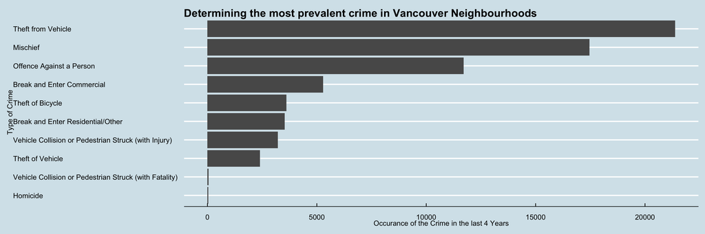

## **Neighborhood Analysis**

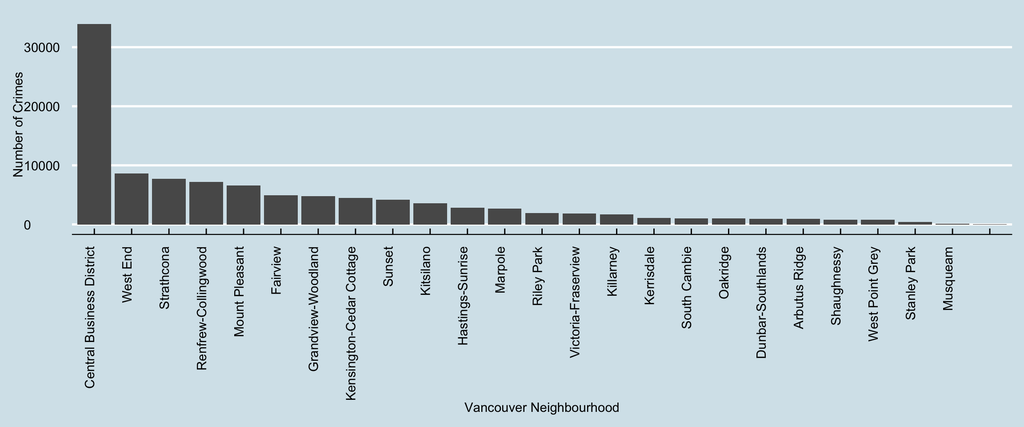

The neighborhoods we have focused on—Central Business District, West End, and Strathcona—are characterized by high crime rates relative to other areas in Vancouver. Each neighborhood presents distinct challenges that are reflected in the crime visualizations.

### Daily Incident Count for Top 3 Crime Types in Vancouver’s Most Dangerous Neighborhoods

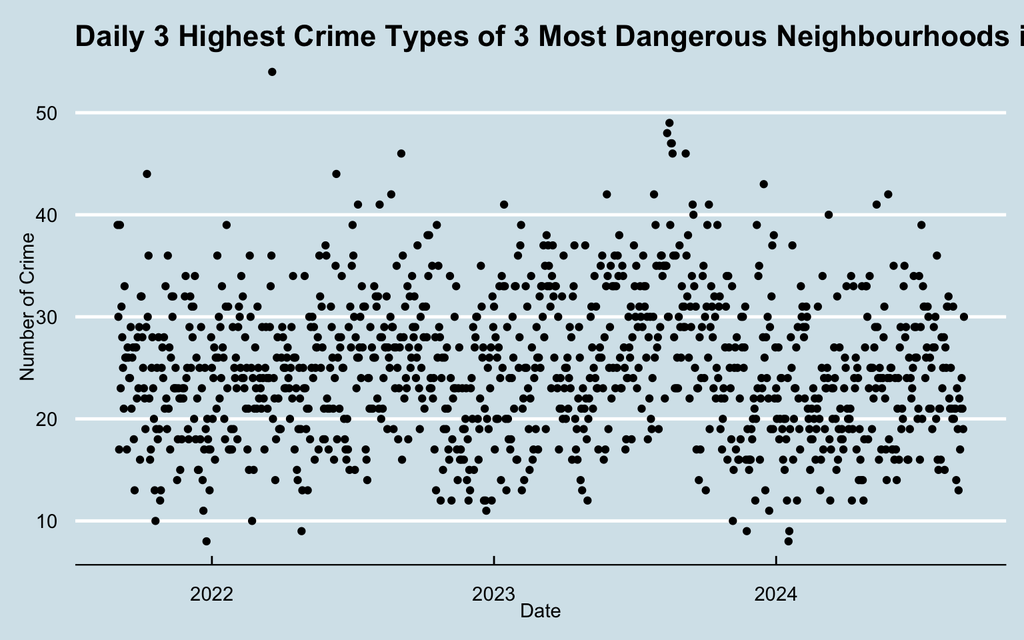

This scatter plot visualizes the number of daily incidents for the top three crime types—Theft from Vehicle, Mischief, and Offence Against a Person—within Vancouver’s Central Business District, West End, and Strathcona neighborhoods. The x-axis represents the date, and the y-axis displays the number of daily incidents.

The plot highlights fluctuations in crime trends over time, providing a clear visual representation of the frequency and intensity of these high-risk crimes from September 1, 2021, to August 31, 2024. This visual serves as a critical tool for understanding the temporal distribution of crime and evaluating potential policy interventions to enhance public safety in these vulnerable areas.

### Trend Analysis of Daily Incidents for Top 3 Crime Types in Vancouver’s Most Dangerous Neighborhoods

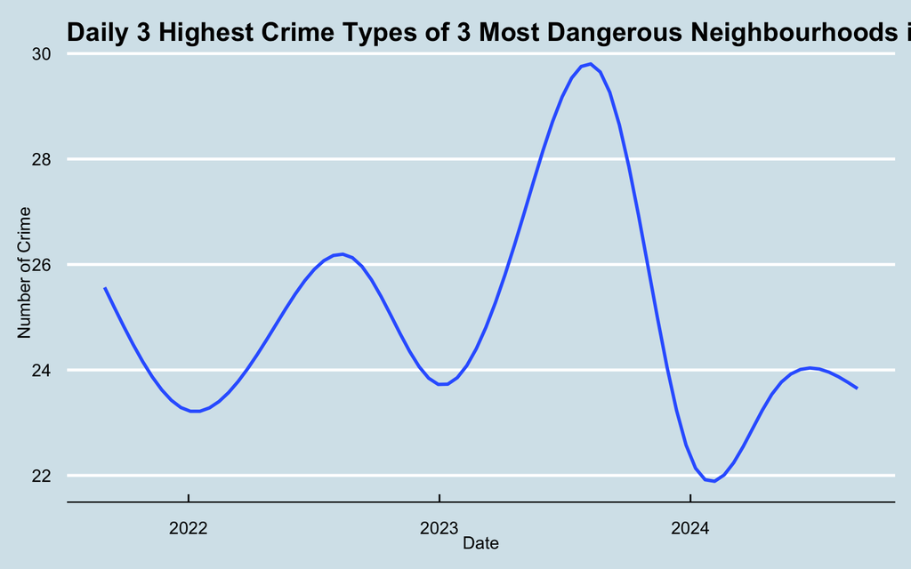

This trend line plot provides a smoothed visualization of the daily incident count for the top three crime types—Theft from Vehicle, Mischief, and Offence Against a Person—in Vancouver’s Central Business District, West End, and Strathcona neighborhoods. The x-axis shows the date, while the y-axis represents the number of daily incidents.

The smoothed line captures the overall trend of crime incidents from September 1, 2021, to August 31, 2024, highlighting significant patterns and changes in crime frequency over time. This analysis helps to identify periods of high activity and assess long-term shifts, offering an alternative way of viewing the same insights for formulating public safety strategies.

### Crime Density Patterns in Vancouver’s High-Risk Neighborhoods

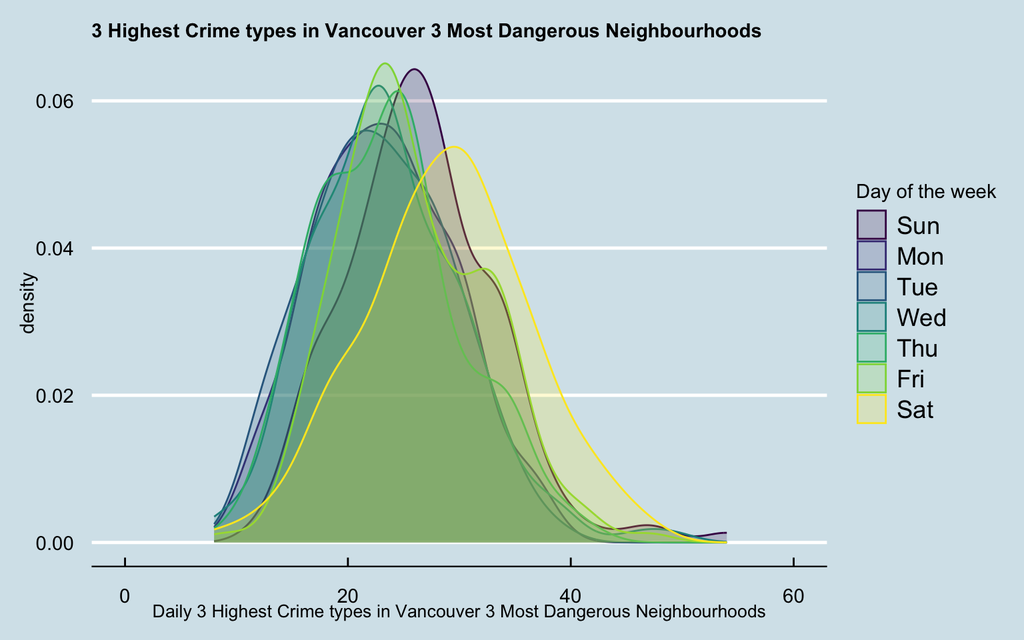

In response to the Mayor’s public safety concerns, this density plot illustrates the distribution of daily crime incidents for the three highest crime types—Theft from Vehicle, Mischief, and Offence Against a Person—within Vancouver’s most dangerous neighborhoods: Central Business District, West End, and Strathcona.

The analysis spans the period from September 1, 2021, to August 31, 2024, providing a comprehensive view of crime trends over time. Each shaded area represents the frequency of daily incidents, with colors differentiating between the days of the week. The x-axis captures the count of daily incidents, capped at 60 for clarity, while the y-axis displays the density of these occurrences.

## **Conclusion and Recommendations:**

Based on the findings from our crime and neighborhood analyses, it is evident that a targeted approach is necessary to enhance public safety in Vancouver. We recommend the following actions:

Strategic Allocation of Police Resources: Increase police patrols and surveillance measures in high-risk areas such as the Central Business District to deter vehicle theft and monitor potential criminal activity.

Community Engagement and Preventative Measures: Launch community engagement programs in the West End to foster a collaborative approach to crime prevention, focusing on mischief-related offences.

Integrated Social Support in Strathcona: Collaborate with local non-profit organizations and healthcare providers to deliver comprehensive social services in Strathcona, addressing homelessness, addiction, and mental health challenges that contribute to crime rates.

## **Appendix**

### Crime Type Analysis Code Chunk

```r
library(tidyverse)
library(ggthemes)
library(lubridate)
crime_data2024 <- read.csv("crimedata_csv_AllNeighbourhoods_2024.csv")
crime_data2023 <- read.csv("crimedata_csv_AllNeighbourhoods_2023.csv")
crime_data2022 <- read.csv("crimedata_csv_AllNeighbourhoods_2022.csv")
crime_data2021 <- read.csv("crimedata_csv_AllNeighbourhoods_2021.csv")
crime_data <- bind_rows(crime_data2024,crime_data2023,crime_data2022,crime_data2021)%>%
  mutate(date = make_date(YEAR,MONTH,DAY))
crime_data.5 <- filter(crime_data,date >= "2021-09-01" & date <= "2024-08-31")

crime_data1 <- group_by(crime_data.5, TYPE)

crime_data2 <- filter(crime_data1, TYPE!="Other Theft")

crime_data3 <-summarise(crime_data2,
                         count_TYPE = n())
ggplot(data = crime_data3, mapping = aes(x = reorder(TYPE,count_TYPE), y= count_TYPE))+labs(x= "Type of Crime", y= "Occurance of the Crime in the last 4 Years", title = "Determining the most prevalent crime in Vancouver Neighbourhoods") + geom_col() +theme_economist() + coord_flip()
```

### Neighborhood Analysis Code Chunk

```r
ncrime_data1 <- group_by(crime_data.5, NEIGHBOURHOOD) %>%
  summarise(count = n())

ggplot(ncrime_data1, mapping = aes(x=reorder(NEIGHBOURHOOD, -count), y=count)) +geom_col() +labs(x="Vancouver Neighbourhood", y="Number of Crimes") + theme_economist() + theme(axis.text.x = element_text(angle = 90, hjust=1))
```

### Daily Incident Count for Top 3 Crime Types in Vancouver’s Most Dangerous Neighborhoods Code Chunk

```r
highest_3_types1<-crime_data.5%>%
  filter(TYPE=="Theft from Vehicle"|TYPE=="Mischief"|TYPE=="Offence Against a Person")%>%
  mutate(date=make_date(YEAR,MONTH,DAY))%>%
  filter(date>="2021-09-01"&date<="2024-08-31")%>%
  filter(NEIGHBOURHOOD=="Central Business District"|NEIGHBOURHOOD=="West End"|NEIGHBOURHOOD=="Strathcona")%>%
  group_by(date)%>%
  summarize(daily_highest_3_crime_types1=n())

highest_3_types1%>%
  ggplot(mapping=aes(x=date,y=daily_highest_3_crime_types1)) +
  geom_point()+
  theme(plot.title = element_text(size = 11))+
  labs(x="Date",y="Number of Crime",
       title = "Daily 3 Highest Crime Types of 3 Most Dangerous Neighbourhoods in Vancouver") +theme_economist()
```

### Trend Analysis of Daily Incidents for Top 3 Crime Types in Vancouver’s Most Dangerous Neighborhoods Code Chunk

```r
b<-highest_3_types1%>%
  ggplot(mapping=aes(x=date,y=daily_highest_3_crime_types1)) +
  geom_smooth(se=FALSE) +
  theme(plot.title = element_text(size = 11))+
  labs(x="Date",
       y="Number of Crime",
       title = "Daily 3 Highest Crime Types of 3 Most Dangerous Neighbourhoods in Vancouver") +theme_economist()
b
```

### Crime Density Patterns in Vancouver’s High-Risk Neighborhoods Code Chunk

```r
highest_3_types1%>% mutate(day_of_week=wday(date, label=TRUE)) %>%
  ggplot(mapping=aes(x=daily_highest_3_crime_types1, fill=day_of_week, color=day_of_week)) +
  geom_density(alpha=0.2) +
  coord_cartesian(xlim=c(0,60)) +
  theme_economist() +
  theme(plot.title = element_text(size = 11),
        axis.title.x = element_text(size = 10),
        legend.position = "right")+
  labs(x="Daily 3 Highest Crime types in Vancouver 3 Most Dangerous Neighbourhoods",
       title = "3 Highest Crime types in Vancouver 3 Most Dangerous Neighbourhoods",
       fill="Day of the week",
       color="Day of the week")
```